# Modeling Relational Data in R with ReDaMoR

ReDaMoR version: 1.0.0

Patrice Godard

May 18 2026

[figure not shown]

# 1 Introduction

In R, data are often stored in data frames which are tables in which each row represents a record and each column a variable. Because data frames are highly used, they have been improved in different objects such as [tibble](https://tibble.tidyverse.org/), [data.table](https://rdatatable.gitlab.io/data.table/) or [AnnotatedDataFrame](https://bioconductor.org/packages/release/bioc/html/Biobase.html).

However, in many projects, the data do not fit in only one table but they are organized in different data frames, each of them dealing with a specific concept. These tables are often related to each other by some variables. Depending on the diversity of the concepts, it can be difficult to remember what these tables represent and how they are connected. Fortunately, because they are tables, a set of data frames can be directly documented using a relational data model.

The datamodelr R package provides tools to document relational data. The generate data models are leveraged by the dm R package to interact more easily with relational data.

Here we present the ReDaMoR package which also allows the manipulation of relational data models in R but with an approach quite different from the one implemented in datamodelr. It provides functions to create, import and save relational data models. These functions are accessible through a graphical user interface made with [Shiny](https://shiny.posit.co/).

The main features of ReDaMoR are the following:

- Create data model from scratch with a graphical user interface
- Save data model in a json format
- Import SQL data model generated with [MySQL Workbench](https://www.mysql.com/products/workbench/)
- Document data types as R types (character, numeric, logical, …)
- Add comments to tables and fields to improve model documentation
- Check and auto-correct model constraints (types, keys, uniqueness, mandatory fields)
- Confront data to the model to check their compatibility

The ReDaMoR R package is licensed under [GPL-3](https://www.gnu.org/licenses/gpl-3.0.en.html) and its source code is available on [github](https://github.com/patzaw/ReDaMoR).

# 2 Installation

## 2.1 From CRAN

```r
install.packages("ReDaMoR")
```

## 2.2 Dependencies

The following R packages available on CRAN are required:

- dplyr: A Grammar of Data Manipulation
- visNetwork: Network Visualization using ‘vis.js’ Library
- readr: Read Rectangular Text Data
- shiny: Web Application Framework for R
- shinyjs: Easily Improve the User Experience of Your Shiny Apps in Seconds
- DT: A Wrapper of the JavaScript Library ‘DataTables’
- rintrojs: Wrapper for the ‘Intro.js’ Library
- colourpicker: A Colour Picker Tool for Shiny and for Selecting Colours in Plots
- jsonlite: A Simple and Robust JSON Parser and Generator for R
- markdown: Render Markdown with ‘commonmark’
- rstudioapi: Safely Access the RStudio API
- crayon: Colored Terminal Output

## 2.3 From github

```r
devtools::install_github("patzaw/ReDaMoR")
```

# 3 Creating and modifying relational data using the graphical user interface

## 3.1 Running the app

The Shiny app is launched with the following command:

```r
library(ReDaMoR)
m <- model_relational_data()
```

When the *Done* button is clicked, the model is returned in R environment. Because the interface can be closed accidentally, the model is also autosaved and can be recovered using the `recover_RelDataModel()` function. The recovered model can be provided as `modelInput` when calling `model_relational_data()`. For example:

```r
m <- model_relational_data(recover_RelDataModel())
```

## 3.2 Model formalism

### 3.2.1 Data model example: the Human Phenotype Ontology

A data model example is provided within the package. It represents data extracted from the [Human Phenotype Ontology (HPO)](https://hpo.jax.org/)<sup>(1)</sup> and for which a subset is also provided within the ReDaMoR package (more details provided in the Confronting data section).

This example can be imported from the Shiny app when clicking on the *Import* button and then on the *Try an example* link. It can be also be loaded and displayed (and edited) using the following commands:

```r
hpo_model <- read_json_data_model(
  system.file("examples/HPO-model.json", package="ReDaMoR")
)
plot(hpo_model)
```

[interactive chart not shown]

```r
## Edit the model
# m <- model_relational_data(hpo_model)
```

The view is rendered by the [visNetwork package](https://datastorm-open.github.io/visNetwork/). It means that it can take advantages of all the functions provided by the visNetwork package including the use of the model in [Shiny apps](https://datastorm-open.github.io/visNetwork/shiny.html).

### 3.2.2 Tables

Each box represents a table. The header of the box corresponds to the name of the table and the following lines document each field:

- The **type** of the field is given between curly brackets
- A star indicates that the field is **unique**
- Fields surrounded by parentheses are **optional**
- Fields in bold are involved in the **primary key**
- **Indexes** are also indicated between the curly brackets when they exist:
  - idx. correspond to regular indexes
  - uidx. correspond to unique indexes

When the cursor is over a box, table and field **comments** are displayed.

### 3.2.3 Foreign keys

Each arrow represent a foreign key:

- The start of the arrow corresponds to the table with the **foreign key**.
- The end of the arrow corresponds to the **referenced table**.
- When the mouse is over the arrow, the **fields** involved in the foreign key are displayed along with the minimum and maximum **cardinalities** of the key on both sides (between brackets below the table name).

## 3.3 App organization

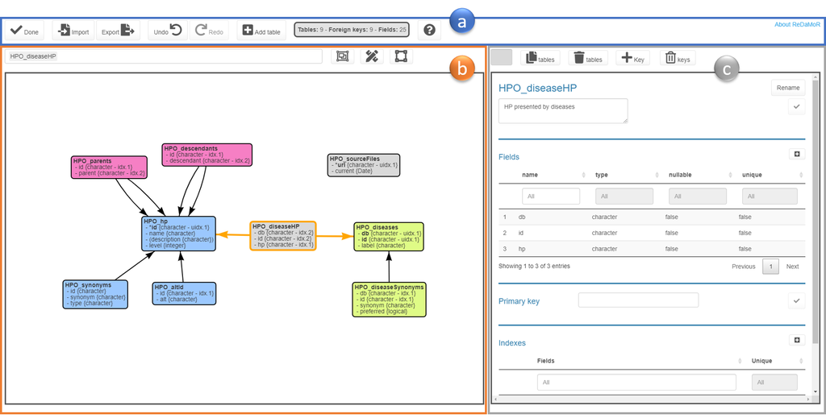

shiny app

The app is divided in three main parts:

- The **main menu** at the top of the page to execute general actions on the model
- The **model view** on the left of the page to interact with the model
- The **edition view** on the right of the page to execute contextual edition of the model

### 3.3.1 The main menu

General actions can be executed on the model, using the buttons in the main menu:

- Import json or sql (Only sql models produced by MySQL Workbench are supported) files
- Export json or html files (a png file can also be saved by right clicking on the model view)
- Add a table

### 3.3.2 The model view

The model view provides a view of the data model rendered by the [visNetwork package](https://datastorm-open.github.io/visNetwork/). Tables can be selected by clicking on it or by searching them using the box just above the model view. Autodraw and autofit capabilities are also provided in this area.

### 3.3.3 The edition view

In the edition view the user can:

- Change the color of a table
- Duplicate or remove tables
- Add and remove foreign keys
- Edit table information
  - table name
  - table comment
  - fields
  - primary key
  - indexes

### 3.3.4 Contextual help tour

An help tour can be launched when clicking on the button in the main menu. This help tour is contextual: its content depends on the state of the app.

### 3.3.5 keyboard shortcuts

Some *common* keyboard shortcuts are implemented:

- **Ctrl+Z** / **Ctrl+Shift+Z** for undo and redo
- **Enter** for validating a new name
- **del** for deleting tables or foreign keys
- **F2** for renaming tables or editing foreign key cardinalities

## 3.4 Public instance of the app

A public instance of the app is available [here](https://pgodard.shinyapps.io/ReDaMoR).

You can easily deploy your own instance by copying these two lines in an *app.R* file:

```r
library(ReDaMoR)
model_relational_data()
```

## Adding foreign keys

In the interface, when you select one or two tables (holding down the ctrl key) you can create a foreign key by clicking on the “Key” button (See in the figure below surrounded in blue).

[figure not shown]

foreign key icon

The following interface should appear:

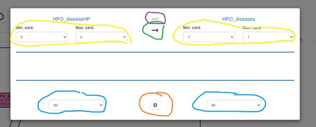

foreign key interface

After having created a relationship you can still change its cardinalities by selecting the relationship of interest and by clicking on the edit “keys” button. If you need to apply more changes, you’ll have to delete the key (“Discard keys” button) and recreate it.

# 4 Confronting data

Data can be confronted to the model using the `confront_data()` function. During this process the following checks are performed:

- All the tables in the model and only those are **available**.
- For each table:
  - All the columns in the model and only those are **available**.
  - The **type** of each column corresponds to the type in the model.
  - Not any *NA* values are found in **non-nullable** columns.
  - There is no duplicated value in **unique** columns.
  - There is no duplicated value in **unique indexes**.
- **Foreign keys** are tested according to their cardinality: all values in on table should be available in the other table if the corresponding minimum cardinality is greater than 0.

A **subset** (500 phenotypes among more than 14 000 in the original resource) of the [HPO](https://hpo.jax.org/)<sup>(1)</sup> is provided within the package and can be directly confronted to the data model. The function prints a report with messages about the global success of the data model confrontation and additional failure or warning messages for relevant tables.

```r
confrontation_report <- confront_data(
  hpo_model,
  path=list.files(
    system.file("examples/HPO-subset", package="ReDaMoR"),
    full.names=TRUE
  ),
  returnData=TRUE
)
```

```
#> Processing "HPO_hp" (table 1 / 9)
#> Processing "HPO_altId" (table 2 / 9)
#> Processing "HPO_sourceFiles" (table 3 / 9)
#> Processing "HPO_diseases" (table 4 / 9)
#> Processing "HPO_diseaseHP" (table 5 / 9)
#> Processing "HPO_diseaseSynonyms" (table 6 / 9)
#> Processing "HPO_parents" (table 7 / 9)
#> Processing "HPO_descendants" (table 8 / 9)
#> Processing "HPO_synonyms" (table 9 / 9)
#> Model
#> SUCCESS
#>
#> Check configuration
#>    - Optional checks: unique, not nullable, foreign keys
#>    - Maximum number of records: Inf
#>
#> HPO_hp
#> SUCCESS
#> Field issues or warnings
#>    - description: SUCCESS Missing values 117/500 = 23%
```

This report can also be formatted using markdown and included in a document such as this one.

```r
# view_confrontation_report(confrontation_report) # Use RStudio viewer
format_confrontation_report_md(
  confrontation_report,
  title="Example: Confrontation with original data",
  level=1, numbered=FALSE
) |>
  cat()
```

## Example: Confrontation with original data

SUCCESS

### Check configuration

- **Optional checks**: unique, not nullable, foreign keys
- **Maximum number of records**: Inf

### HPO_hp

SUCCESS

#### Field issues or warnings

- description: SUCCESS Missing values 117/500 = 23%

The `returnData` argument is used to keep the data in the confrontation report.

```r
hpo_tables <- confrontation_report$data
```

In the example below the data are altered and confronted again to the data model. The confrontation report shows the discrepancies between the model and the data in order to facilitate the correction of one or the other.

```r
hpo_tables$HPO_diseases <- hpo_tables$HPO_diseases |> slice(1:100)
hpo_tables$HPO_synonyms[1:10, "synonym"] <- NA
hpo_tables$HPO_hp <- hpo_tables$HPO_hp |> mutate(level=as.character(level))
confront_data(hpo_model, hpo_tables, verbose=FALSE) |>
  format_confrontation_report_md(
    title="Example: Confrontation with altered data",
    level=1, numbered=FALSE
  ) |>
    cat()
```

## Example: Confrontation with altered data

FAILURE

### Check configuration

- **Optional checks**: unique, not nullable, foreign keys
- **Maximum number of records**: Inf

### HPO_hp

FAILURE

#### Field issues or warnings

- description: SUCCESS Missing values 117/500 = 23%
- level: FAILURE Unexpected “character”

### HPO_diseaseHP

FAILURE

#### Foreign keys issues or warnings

- HPO_diseases [db->db + id->id]: FAILURE All keys of HPO_diseaseHP should be available in HPO_diseases.

### HPO_diseaseSynonyms

FAILURE

#### Foreign keys issues or warnings

- HPO_diseases [db->db + id->id]: FAILURE All keys of HPO_diseaseSynonyms should be available in HPO_diseases.

### HPO_synonyms

FAILURE

#### Field issues or warnings

- synonym: FAILURE Missing values 10/730 = 1%

## 4.1 Drafting a data model from data frames

Beside confronting a model to data, a model can also be drafted from a set of tables. Only column names and types are documented during this process. Uniqueness, mandatory and key constraints still need to be documented by the user to complete the model. From version 0.8.0, the function `guess_constraints()` guesses unique and non-nullable fields, along with potential foreign keys, based on the provided or existing tables. The guessed constraints should be carefully reviewed, especially the foreign keys. This can be easily done with `model_relational_data()`.

```r
hpo_tables <- confrontation_report$data

## Build the model from a list of data frames ----
new_model <- df_to_model(
   list=names(hpo_tables), envir=as.environment(hpo_tables)
)
## Guess constraints and auto layout ----
new_model <- guess_constraints(new_model, data = hpo_tables) |>
   auto_layout(lengthMultiplier=250)

## Plot the model ----
new_model |>
   plot()
```

[interactive chart not shown]

```r
# model_relational_data(new_model)
```

# 5 Support of matrices

Matrices (2 dimensions) are supported by ReDaMoR (>= 0.5). A matrix is modeled as a table with 3 and only 3 fields: 2 of types *row* and *column* and the third of your choice. The *row* and *column* compose the primary index of this special table, but they cannot be unique independently (a cell in a matrix is always identified by its row and its column). The example below shows a model of a *gene_expression* matrix: the rows correspond to genes, the column to samples and the value to the gene expression value in each sample. Genes and samples are further described in the *genes* and *samples* tables.

```r
ge_model <- read_json_data_model(
  system.file("examples/GE-model.json", package="ReDaMoR")
)
plot(ge_model)
```

[interactive chart not shown]

# 6 TKCat: Tailored Knowledge Catalog

The aim of [TKCat](https://patzaw.github.io/TKCat/) (Tailored Knowledge Catalog) is to facilitate the management of data from knowledge resources that are frequently used alone or together in research environments. In TKCat, knowledge resources are manipulated as modeled database (MDB) objects. These objects provide access to the data tables along with a general description of the resource and a detail data model generated with ReDaMoR documenting the tables, their fields and their relationships. These MDB are then gathered in catalogs that can be easily explored an shared. TKCat provides tools to easily subset, filter and combine MDBs and create new catalogs suited for specific needs.

`MDB` objects can be subsetted, combined, filtered, joined and merged. [TKCat](https://patzaw.github.io/TKCat/) supports different implementations of `MDB` objects such as `memoMDB` (data in memory), `fileMDB` (data in files) and `chMDB` (data in [ClickHouse](https://clickhouse.com/) database). More information is provided in the [TKCat user guide](https://patzaw.github.io/TKCat/articles/TKCat.html).

# 7 Acknowledgments

This work was entirely supported by [UCB Pharma](https://www.ucb.com/). (Early Solutions department)

# 8 References

**(1)** [Sebastian Köhler, Leigh Carmody, Nicole Vasilevsky, Julius O B Jacobsen, et al. **Expansion of the Human Phenotype Ontology (HPO) knowledge base and resources.** *Nucleic Acids Research.* (2018) doi: 10.1093/nar/gky1105](https://doi.org/10.1093/nar/gky1105)